# Day 6 - Spatial Data Viz Exercises

Bryan Goodrich

January 6, 2017

# Descriptive Analytics - Part 5

## Data Visualization - Spatial Data

http://r-exercises.com/2016/12/26/descriptive-analytics-part-5-data-visualisation-spatial/

Having seen these come across my RSS feeds before, I think they do a great job sometimes just laying out quick exercises to challenge you to do something new. I have special interest in spatial data analysis and visualization coming from a GIS background late in my academic career–needed something to study after graduation to stay off loans! While I hope to do more spatial stuff in this series, I thought this would be a nice starter, especially since I’ve never touched the GG stuff around it.

I’ll leave it to you to get the 2008 data set, run the author’s code to prep it, and have everything ready to go, because I’m not including that here.

Now let’s dig in!

```r
# Libraries
library(dplyr)
library(ggplot2)
library(ggmap)

# read in your data!
flights <- readRDS("data/flights2008.Rds")
airports <- read.csv("data/airports.csv", stringsAsFactors = FALSE)

# Needed changes
flights <- mutate(flights,
                  Origin = as.character(Origin),
                  Dest = as.character(Dest),
                  day_of_week = weekdays(as.Date(Full_Date, origin='1970-01-01')))
```

### Exercise 1

Query the map of United States using the get_map function. It is recommended to experiment with the various types of maps and select the one that you think is the best. (I have used the toner-lite from Stamen Maps.)

```r
usmap <- get_map("united states", maptype = "toner-lite", zoom=4, filename = "day/data/usmap", source ='stamen')
```

### Exercise 2 + 3

Print the map that you have selected.

Modify the printed map in order to print out a bigger image( extent) and assign it to a m object.

```r
m <- ggmap(usmap)
```

### Exercise 4

Plot the destination airports of the flights on the map.

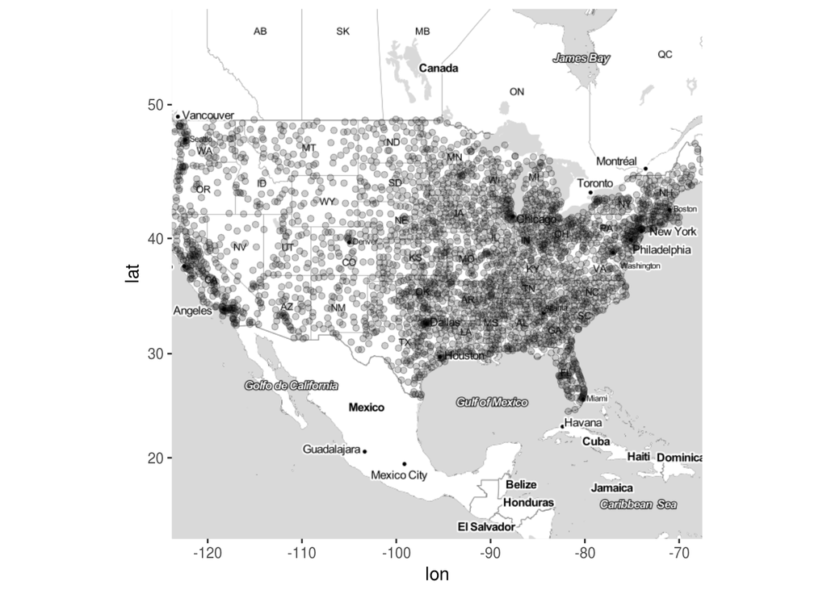

```r
m + geom_point(aes(long, lat), data = airports, alpha = 0.2)  # Lots of overplotting!
```

### Exercise 5

Plot the destination airports of the flights on the map, the size of the points should be based on the number of flights that arrived to the destination airports.

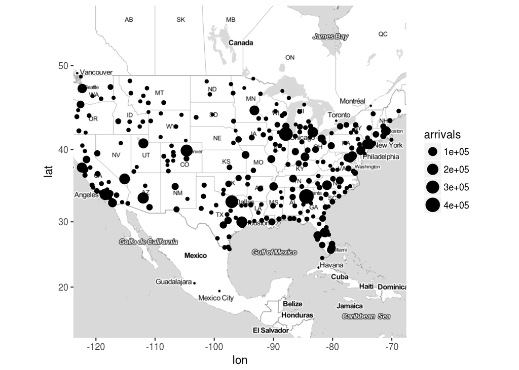

```r
x <- flights %>%
    group_by(Dest) %>%
    summarise(arrivals = n()) %>%
    inner_join(airports, by = c("Dest" = "iata"))
m + geom_point(aes(long, lat, size = arrivals), data = x)
```

### Exercise 6

Plot the destination airports of the flights on the map, the colour of the points should be based on the number of flights that arrived to the destination airport. Make it a bit prettier, use the scale_colour_gradient and set the lows and the highs of your preferences.

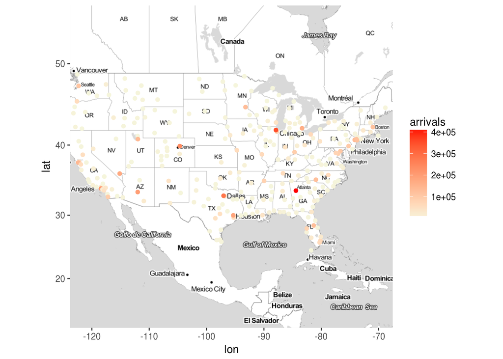

```r
x <- flights %>%
    group_by(Dest) %>%
    summarise(arrivals = n()) %>%
    inner_join(airports, by = c("Dest" = "iata"))
m + geom_point(aes(long, lat, color = arrivals), data = x) +
    scale_color_gradient(low='beige', high='red')
```

### Exercise 7

Plot the destination airports of the flights on the map, the colour of the points should be based on the number of flights that arrived to the destination airport and the size of the points should be based on the total delay of arrival of the flights that arrived at the destination airport. Something is not right here, right?

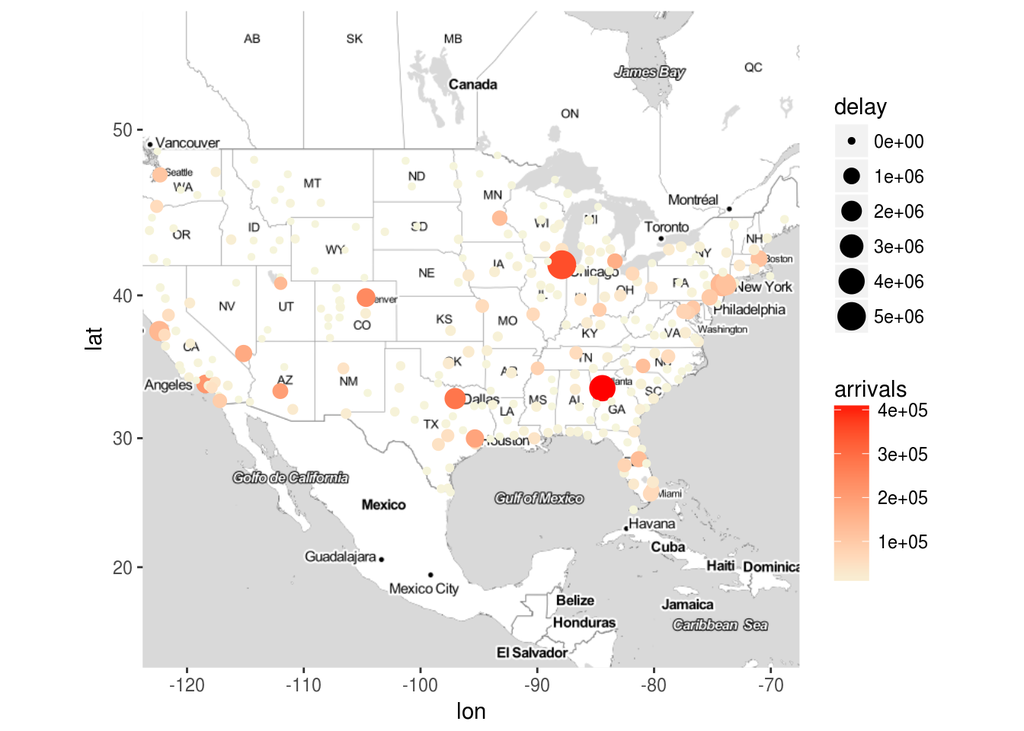

```r
x <- flights %>%
    group_by(Dest) %>%
    summarise(arrivals = n(), delay = sum(ArrDelay)) %>%
    inner_join(airports, by = c("Dest" = "iata"))
m + geom_point(aes(long, lat, color = arrivals, size = delay), data = x) +
    scale_color_gradient(low='beige', high='red')
```

### Exercise 8

Plot the destination airports of the flights on the map, the colour of the points should be based on the number of flights that arrived to the destination airport and the size of the points should be based on the total delay of arrival divided by the number of flights per destination.

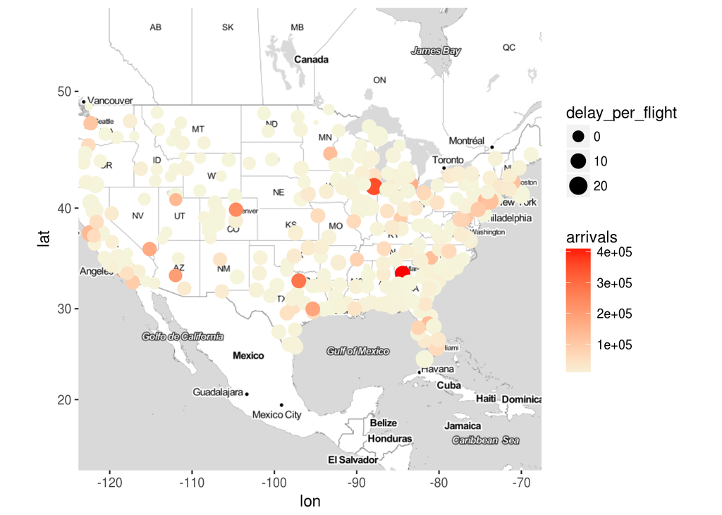

```r
x <- flights %>%
    group_by(Dest) %>%
    summarise(arrivals = n(), delay = sum(ArrDelay)) %>%
    mutate(delay_per_flight = delay / arrivals) %>%
    inner_join(airports, by = c("Dest" = "iata"))
m + geom_point(aes(long, lat, color = arrivals, size = delay_per_flight), data = x) +
    scale_color_gradient(low='beige', high='red')
```

### Exercise 9

Plot the destination airports for everyday of the week (hint : facet_wrap )

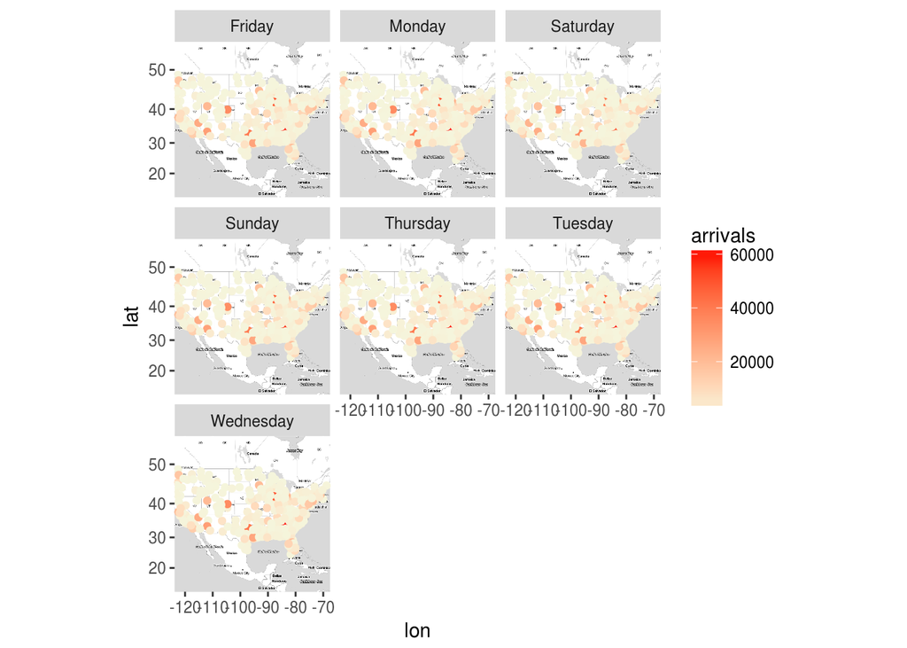

```r
x <- flights %>%
    group_by(Dest, day_of_week) %>%
    summarise(arrivals = n(), delay = sum(ArrDelay)) %>%
    mutate(delay_per_flight = delay / arrivals) %>%
    inner_join(airports, by = c("Dest" = "iata"))
m + geom_point(aes(long, lat, color = arrivals), data = x) +
    scale_color_gradient(low='beige', high='red') +
    facet_wrap(~day_of_week)
```

### Exercise 10

Plot the destination airports of the flights on the map, the colour of the points should be based on the number of flights that arrived to the destination airports, the size of the points should be based on the total delay of arrival of the flights that arrived at the destination airport for everyday of the week. (This may be a bit more challenging , if you can’t solve it go to the solutions and try to understand the reason I did what I did, if you have any questions please post them at the comment section).

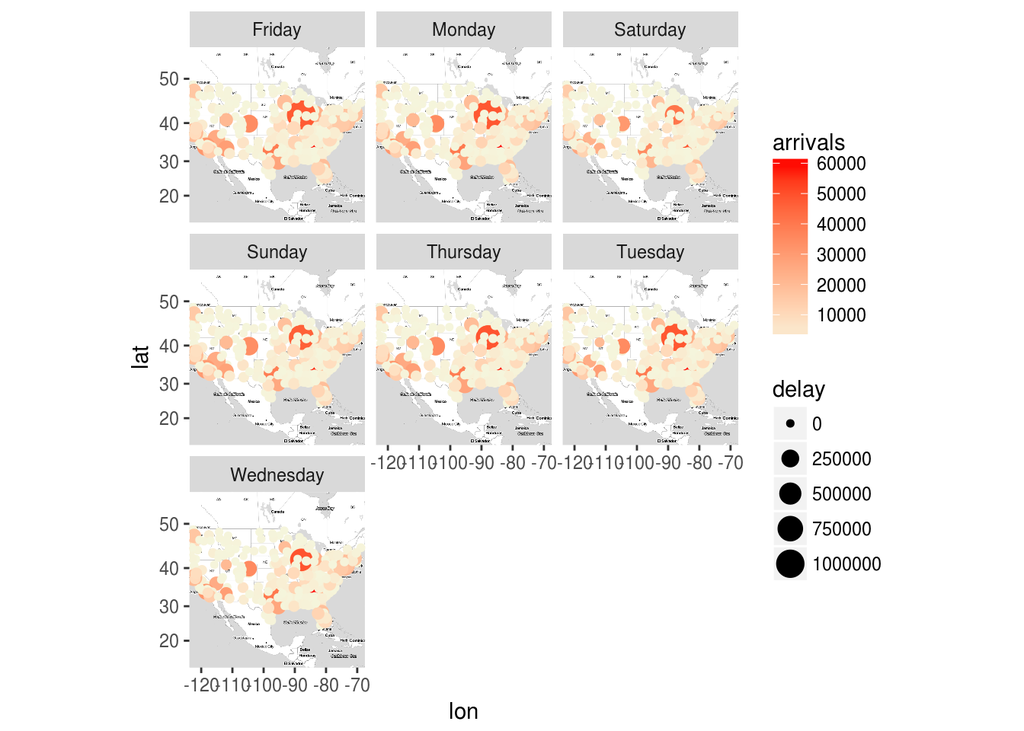

```r
x <- flights %>%
    group_by(Dest, day_of_week) %>%
    summarise(arrivals = sum(ifelse(Cancelled == 0, 1, 0)), delay = sum(ArrDelay)) %>%
    mutate(delay_per_flight = delay / arrivals) %>%
    inner_join(airports, by = c("Dest" = "iata"))
m + geom_point(aes(long, lat, color = arrivals, size = delay), data = x) +
    scale_color_gradient(low='beige', high='red') +
    facet_wrap(~day_of_week)
```

# Closing Remarks

This was a fun exercise. There is plenty that can be done to make this better, but that’s for another day!